# Multiple Lineare Regression

## Homoscedasticity

```
OK: Error variance appears to be homoscedastic (p = 0.294).
```

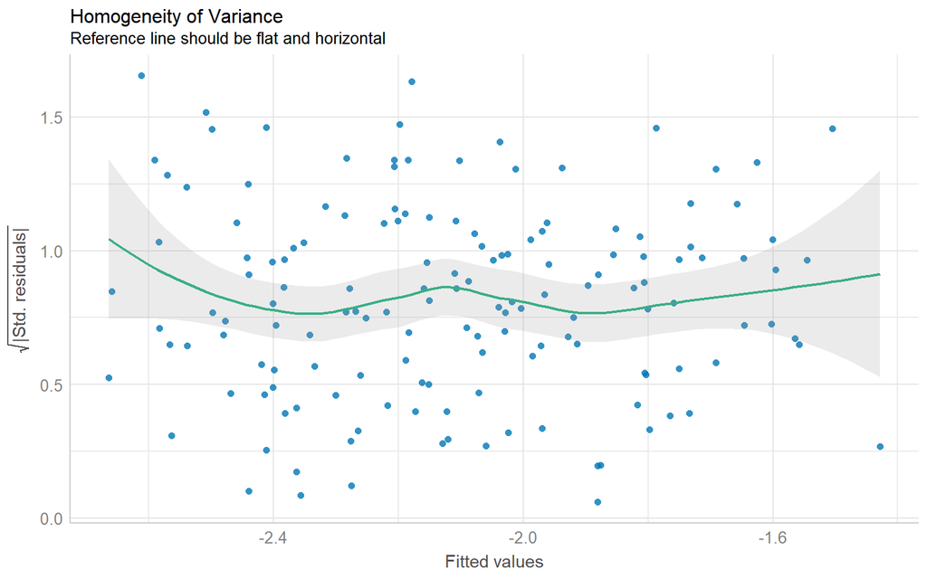

```r
library(performance)

plot(check_heteroscedasticity(lm_final))
```

Data points should be spread equally around the line, with no obvious patterns visible.

## Normality

```
OK: residuals appear as normally distributed (p = 0.374).
```

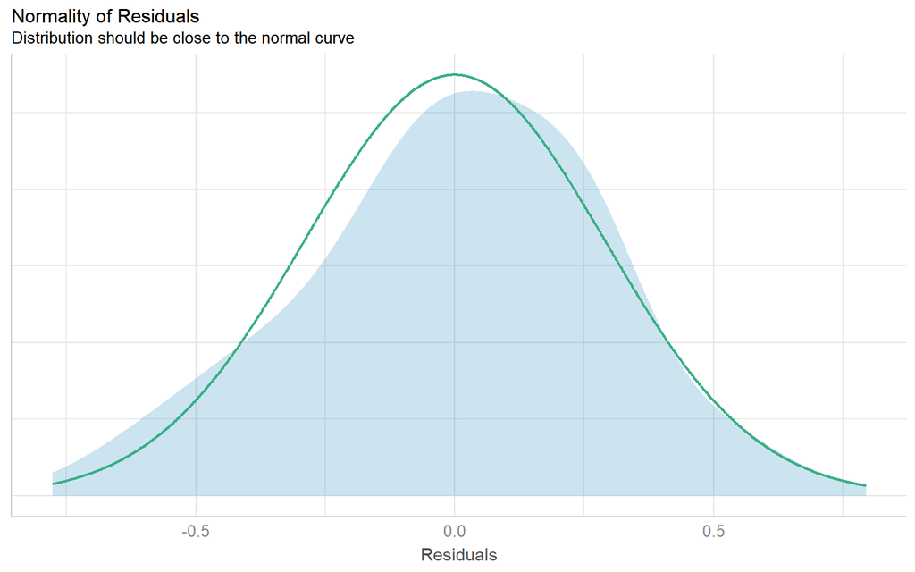

```r
library(performance)

plot(check_normality(lm_final))
```

The distribution of a linear model’s residuals should be normally distributed as indicated by the greenish/blueish curve.

## Independence

Independence cannot be checked visually. It is an assumption that you can test by examining the study design.

# 05 Aufgaben

Aus `data_s`:

- `sDurLog` ~ `bsex` + `age` + `location`
- `sDurLog` ~ `typeOfS` + `pauseBin`
- `sDurLog` ~ `baseDurLog` + `speakingRate`
- `sDurLog` ~ `biphoneProbSumBin` + `folType` + `preC`
- `sDurLog` ~ `bsex` + `age` + `location` + `typeOfS` + `pauseBin` + `baseDurLog` + `speakingRate` + `biphoneProbSumBin` + `folType` + `preC`

Aus `data_a`:

- `height` ~ `bsex` + `hair`
- `height` ~ `hair` + `eyes`
- `height` ~ `bsex` + `hair` + `hair` + `eyes`

Aus `data_v`:

`duration` ~ `vowel` + `structure` + `rate`